# Latihan pertemuan 4-MPDW

# White Noise

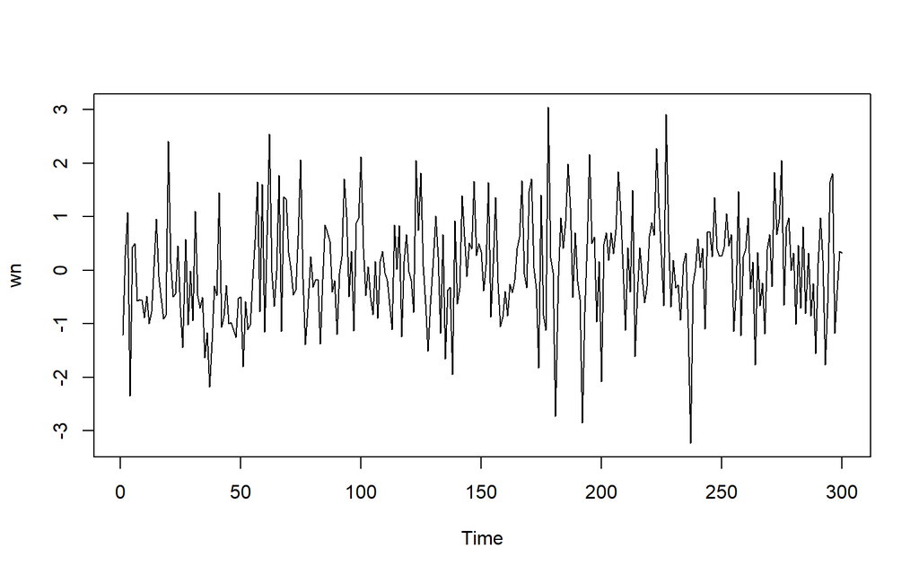

```r
set.seed(1234)
wn <- rnorm(300)
ts.plot(wn)
```

```r
n<-length(wn)
n
```

```
## [1] 300
```

# Proses MA(2)

*Bangkitkan model MA(2) dengan 𝜃1 = 0.4 dan 𝜃2 = 0.6 sebanyak 300 data (Manual dan dengan arima.sim)*

Proses MA dapat dituliskan sebagai berikut:

## Dengan Manual

```r
ma2 <- c(1:n)
ma2[1] <- wn[1]
ma2[2] <- wn[2]+0.4*wn[1]
for (i in 3:n) {
  ma2[i]<-wn[i]+0.4*wn[i-1]+0.6*wn[i-2]
  }
ma2
```

```
##   [1] -1.207065749 -0.205397058  0.471173424 -1.745463687  0.141510314
##   [6] -0.729712854 -0.114842790 -0.472894305 -1.127948717 -1.443797742
##  [11] -1.171879031 -1.723286222 -1.461924092 -0.845074607  0.519525249
##  [16]  0.312187420  0.020572732 -1.181770516 -1.508255550  1.534249256
##  [21]  0.598119283  1.012450498 -0.556369299 -0.011041246 -0.774213194
##  [26] -1.449939345 -0.420758391 -1.662676381 -0.079747157 -1.556197355
##  [31]  0.718835126 -0.596243221 -0.238298741 -1.070389923 -2.255260716
##  [36] -2.120011486 -3.624543435 -2.913580609 -2.138714925 -1.388210999
##  [41]  1.086560934 -0.768382742 -0.413123964 -1.263954490 -1.619808057
##  [46] -1.534624150 -2.091327966 -2.276021753 -1.689013389 -1.457572736
##  [51] -2.319068111 -1.602598402 -2.425338748 -1.807763414 -1.233628102
##  [56] -0.110845196  1.775654086  0.223607057  2.285258743 -0.979456751
##  [61]  1.157010823  2.116941328  1.378789117  0.845856907 -0.296314421
##  [66]  1.372262398 -0.432336811  1.978634754  1.193531021  1.688995021
##  [71]  0.939220832 -0.250827924 -0.544575725  0.228395751  2.109671129
```

[output cut: 45 more lines]

## Dengan Arima.sim()

```r
ma2sim <- arima.sim(list(order=c(0,0,2), ma=c(0.4,0.6)), n=300)
ma2sim
```

```
## Time Series:
## Start = 1
## End = 300
## Frequency = 1
##   [1] -0.908714261  0.366069559  0.319892749 -0.033692645 -0.749809541
##   [6]  1.023224875 -0.103827746  1.553027734  1.508813504  1.490258435
##  [11]  0.638775303  0.057508568 -0.761313741  1.006804154  0.046165301
##  [16]  2.226792228 -0.031351321  0.058227766 -0.452682262 -0.306828839
##  [21] -0.408896770 -1.768664231 -0.905163217 -1.653388217  0.814020129
##  [26] -0.949587092  1.394975120 -0.770061199  0.708742509  0.626264945
##  [31]  0.016220780  0.886163244 -0.177443664 -0.837739266 -0.776948985
##  [36]  0.830630275  0.271737011  0.068438994 -0.509614613 -0.182137038
##  [41]  1.054967504  1.724174690  1.131301118  1.891160132 -0.238116411
##  [46] -1.951472236 -1.868044756 -2.111236903 -2.805388403 -0.673455997
##  [51] -1.948408128 -0.202080988 -2.147789666 -0.222949385  1.157974906
```

[output cut: 49 more lines]

# Karakterisitik MA(2)

*Buat plot time series, plot ACF, plot PACF dan plot EACF. Idenifikasi apakah data tersebut stasioner*

## Plot Time Series

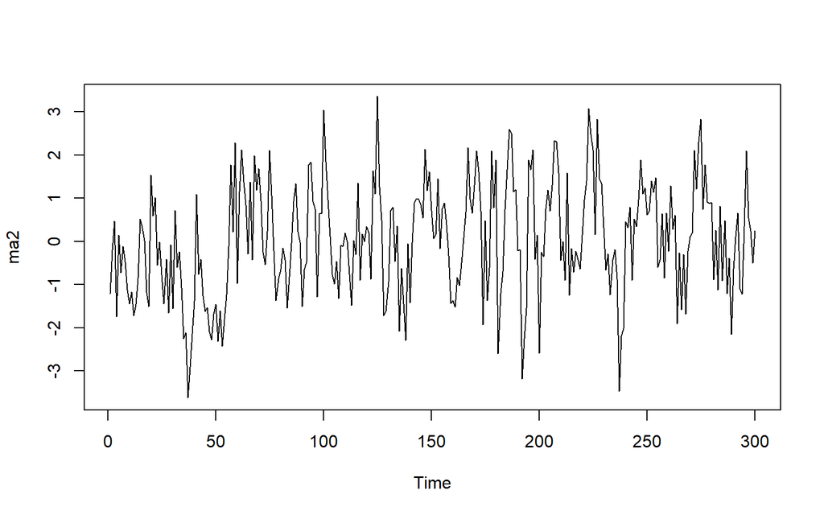

```r
ts.plot(ma2)
```

Dari plot tersebut terlihat bahwa data MA(2) dibangkitkan stasioner dalam rataan

## Plot ACF

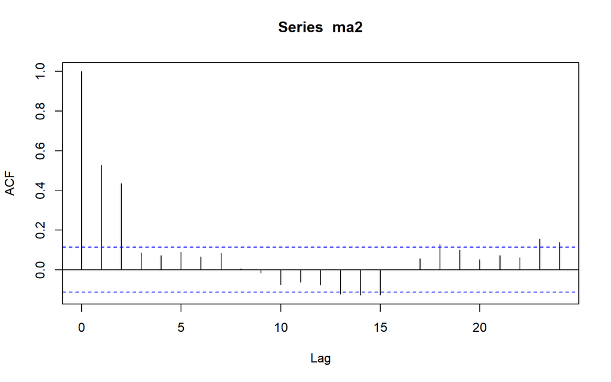

```r
acf(ma2)
```

Berdasarkan plot ACF tersebut, terlihat bahwa plot ACF **cuts off** setelah lag kedua

## Plot PACF

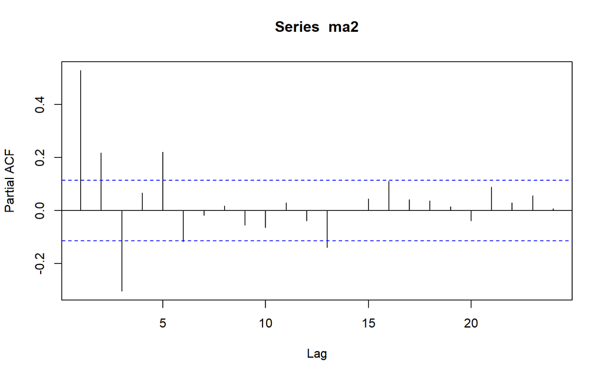

```r
pacf(ma2)
```

Berdasarkan plot PACF tersebut, terlihat bahwa plot PACF **tails off**

## Plot EACF

```r
TSA::eacf(ma2)
```

```
## AR/MA
##   0 1 2 3 4 5 6 7 8 9 10 11 12 13
## 0 x x o o o o o o o o o  o  x  x
## 1 x x x o o o o o o o o  o  o  o
## 2 x x x x o o o o o o o  o  o  o
## 3 x x x x x o o o o o o  o  o  o
## 4 x x x x x o o o o o o  o  o  o
## 5 x x o x x o x o o o o  o  o  o
## 6 x x x o x o o x o o o  o  o  o
## 7 x o x o x o o x o o o  o  o  o
```

Berdasarakan plot EACF, terlihat bahwa segitiga nol berada pada ordo AR(0) dan ordo MA(2)

# Scatterplot Antar Lag MA(2)

*Buat scatterplot antara 𝑌𝑡 dengan 𝑌𝑡−1, 𝑌𝑡 dengan 𝑌𝑡−2 serta 𝑌𝑡 dengan 𝑌𝑑−3*

## Korelasi $Y_t$ dengan $Y_{t-1}$

```r
#Yt
yt_ma2 <- ma2[2:300]
yt_ma2
```

```
##   [1] -0.205397058  0.471173424 -1.745463687  0.141510314 -0.729712854
##   [6] -0.114842790 -0.472894305 -1.127948717 -1.443797742 -1.171879031
##  [11] -1.723286222 -1.461924092 -0.845074607  0.519525249  0.312187420
##  [16]  0.020572732 -1.181770516 -1.508255550  1.534249256  0.598119283
##  [21]  1.012450498 -0.556369299 -0.011041246 -0.774213194 -1.449939345
##  [26] -0.420758391 -1.662676381 -0.079747157 -1.556197355  0.718835126
##  [31] -0.596243221 -0.238298741 -1.070389923 -2.255260716 -2.120011486
##  [36] -3.624543435 -2.913580609 -2.138714925 -1.388210999  1.086560934
##  [41] -0.768382742 -0.413123964 -1.263954490 -1.619808057 -1.534624150
##  [46] -2.091327966 -2.276021753 -1.689013389 -1.457572736 -2.319068111
##  [51] -1.602598402 -2.425338748 -1.807763414 -1.233628102 -0.110845196
##  [56]  1.775654086  0.223607057  2.285258743 -0.979456751  1.157010823
##  [61]  2.116941328  1.378789117  0.845856907 -0.296314421  1.372262398
##  [66] -0.432336811  1.978634754  1.193531021  1.688995021  0.939220832
##  [71] -0.250827924 -0.544575725  0.228395751  2.109671129  1.063681873
```

[output cut: 45 more lines]

```r
#Yt-1
yt_1_ma2 <- ma2[1:299]
yt_1_ma2
```

```
##   [1] -1.207065749 -0.205397058  0.471173424 -1.745463687  0.141510314
##   [6] -0.729712854 -0.114842790 -0.472894305 -1.127948717 -1.443797742
##  [11] -1.171879031 -1.723286222 -1.461924092 -0.845074607  0.519525249
##  [16]  0.312187420  0.020572732 -1.181770516 -1.508255550  1.534249256
##  [21]  0.598119283  1.012450498 -0.556369299 -0.011041246 -0.774213194
##  [26] -1.449939345 -0.420758391 -1.662676381 -0.079747157 -1.556197355
##  [31]  0.718835126 -0.596243221 -0.238298741 -1.070389923 -2.255260716
##  [36] -2.120011486 -3.624543435 -2.913580609 -2.138714925 -1.388210999
##  [41]  1.086560934 -0.768382742 -0.413123964 -1.263954490 -1.619808057
##  [46] -1.534624150 -2.091327966 -2.276021753 -1.689013389 -1.457572736
##  [51] -2.319068111 -1.602598402 -2.425338748 -1.807763414 -1.233628102
##  [56] -0.110845196  1.775654086  0.223607057  2.285258743 -0.979456751
##  [61]  1.157010823  2.116941328  1.378789117  0.845856907 -0.296314421
##  [66]  1.372262398 -0.432336811  1.978634754  1.193531021  1.688995021
##  [71]  0.939220832 -0.250827924 -0.544575725  0.228395751  2.109671129
```

[output cut: 45 more lines]

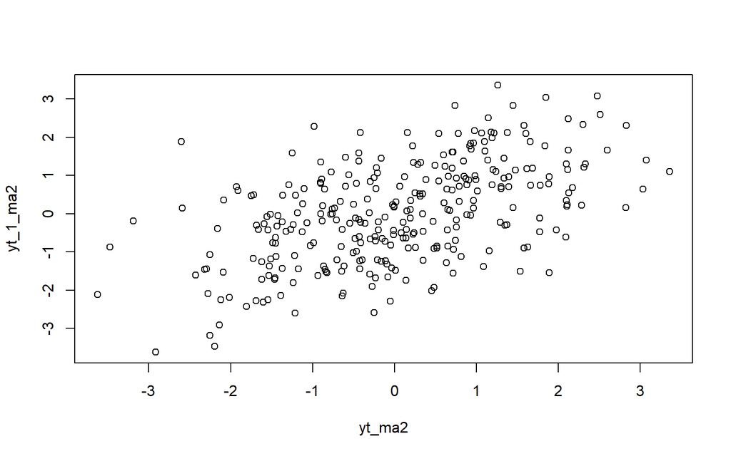

```r
#plot Yt dengan Yt-1
plot(yt_ma2,yt_1_ma2)
```

Berdasarkan scatterplot tersebut, terlihat bahwa data MA(2) memiliki korelasi positif yang sedikit rendah antara $Y_t$ dengan $Y_{t-1}$.

```r
#korelasi Yt dengan Yt-1
cor(yt_ma2,yt_1_ma2)
```

```
## [1] 0.5282201
```

Saat dicek dengan korelasi secara teoritis hasil yang hampir mirip dengan simulasi, yaitu

$$\rho_1=\frac{-\theta+\theta_1\theta_2}{1+(\theta_1)^2+(\theta_2)^2}=\frac{-(-0.4)*(-0.4)*(-0.6)}{1+(-0.4)^2+(-0.6)^2}=0.42$$

## Korelasi $Y_t$ dengan $Y_{t-2}$

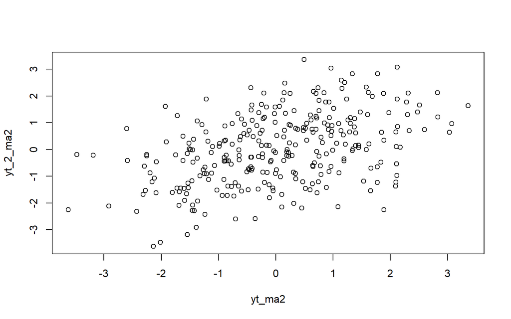

```r
#Yt
yt_ma2 <- ma2[3:300]

#Yt-2
yt_2_ma2 <- ma2[1:298]

#plot Yt dengan Yt-2
plot(yt_ma2,yt_2_ma2)
```

Berdasarkan scatterplot tersebut, terlihat bahwa data MA(2) antara $Y_t$ dengan $Y_{t-2}$ memiliki korelasi positif yang lebih rendah dari $Y_t$ dengan $Y_{t-1}$.

```r
#korelasi Yt dengan Yt-2
cor(yt_ma2,yt_2_ma2)
```

```
## [1] 0.4356204
```

## Korelasi $Y_t$ dengan $Y_{t-3}$

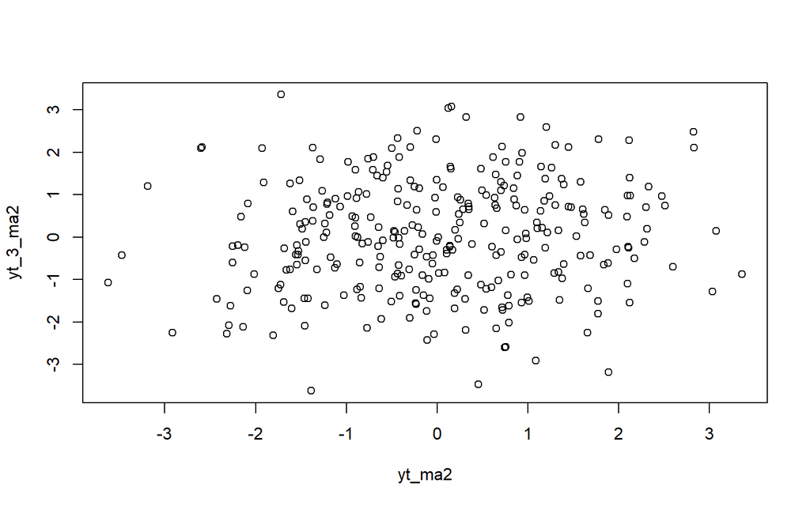

```r
#Yt
yt_ma2 <- ma2[4:300]

#Yt-3
yt_3_ma2 <- ma2[1:297]

#plot Yt dengan Yt-3
plot(yt_ma2,yt_3_ma2)
```

Berdasarkan scatterplot tersebut, terlihat bahwa data MA(2) cenderung tidak memiliki korelasi antara $Y_t$ dengan $Y_{t-3}$. Hal ini menandakan bahwa data MA(2) memiliki maksimum korelasi di ordo ke 2

```r
#korelasi Yt dengan Yt-3
cor(yt_ma2,yt_3_ma2)
```

```
## [1] 0.08544546
```

# Proses AR(2)

*Bangkitkan model AR(2) dengan 𝜙1 = 0.5 dan 𝜙2 = 0.2 sebanyak 300 data (Manual dan dengan arima.sim)*

Proses AR dapat dituliskan sebagai berikut:

$$y_{t} = c + e_t + \phi_{1}Y_{t-1} +
\phi_{2}Y_{t-2} + \dots + \phi_{q}Y_{t-q} = c+{e_t+\sum_{i=1}^p
\phi_iY_{t-i}}$$

Terlihat bahwa $Y_t$ berperan penting dalam pembangkitan proses AR.

Pada kesempatan kali ini, kita akan membahas proses AR(2) yang memiliki dua parameter autoregresi, yaitu $0.5$ dan $0.2$, sehingga menghasilkan persamaan sebagai berikut :

$$y_{t} = e_t + {0.5}Y_{t-1} + {0.2}Y_{t-2}$$

## Dengan Manual

```r
ar2 <- c(1:n)
ar2[1] <- wn[1]
ar2[2] <- wn[2]+0.5*ar2[1]
for (i in 3:n) {ar2[i]<-wn[i]+0.5*ar2[i-1]+0.2*ar2[i-2]}
ar2
```

```
##   [1] -1.207065749 -0.326103633  0.679976211 -2.070930324 -0.470345231
##   [6] -0.143302788 -0.740460400 -0.945522614 -1.185305386 -1.671795045
##  [11] -1.550151299 -2.107821103 -2.140194706 -1.427202757 -0.182146261
##  [16] -0.486799176 -0.790838346 -1.403974425 -1.697326562  1.286377013
##  [21]  0.437811414 -0.014504787 -0.360237983  0.276569492 -0.627483098
##  [26] -1.706632561 -0.404057179 -1.567010825 -0.879455148 -1.689078340
##  [31]  0.081867346 -0.772475074 -1.079304105 -1.195405128 -2.442656854
##  [36] -2.628028715 -3.982585377 -3.857891624 -3.019756746 -2.747354238
##  [41] -0.528132203 -1.882179673 -1.902080911 -1.608099392 -2.178805954
##  [46] -2.379537173 -2.732847970 -3.094317305 -2.617556366 -2.424491601
##  [51] -3.541788331 -2.837868410 -3.236181496 -3.200626439 -2.409859042
##  [56] -1.281998990  0.524846169 -0.767330137  1.327213794 -0.647667678
##  [61]  0.598197384  2.718556227  1.444157201  0.596156266  0.579304817
##  [66]  2.185968110  0.070237282  1.840139442  2.263681968  1.836341670
##  [71]  1.377800067  0.600699629  0.209385895  0.873119441  2.548707761
```

[output cut: 45 more lines]

## Dengan Arima.sim()

```r
ar2sim <- arima.sim(list(order=c(2,0,0), ar2=c(0.5,0.2)), n=300)
ar2sim
```

[output not shown]

[output cut: 49 more lines]

# Karakterisitik AR(2)

*Buat plot time series, plot ACF, plot PACF dan plot EACF. Idenifikasi apakah data tersebut stasioner*

## Plot Time Series

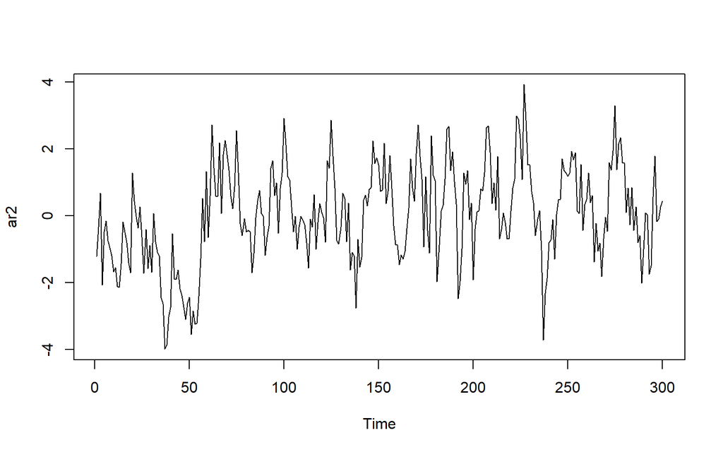

```r
ts.plot(ar2)
```

Dari plot tersebut terlihat bahwa data AR(2) dibangkitkan stasioner dalam rataan

## Plot ACF

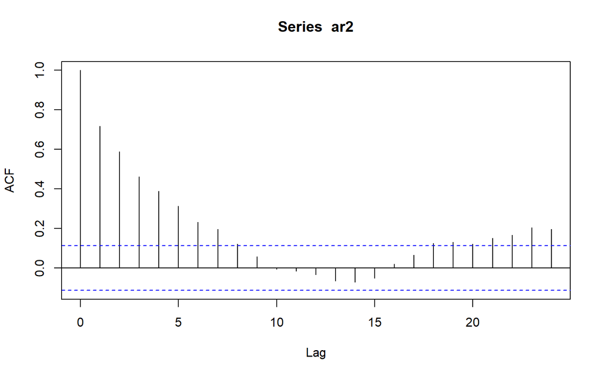

```r
acf(ar2)
```

Berdasarkan plot ACF tersebut, terlihat bahwa plot ACF **tails off**

## Plot PACF

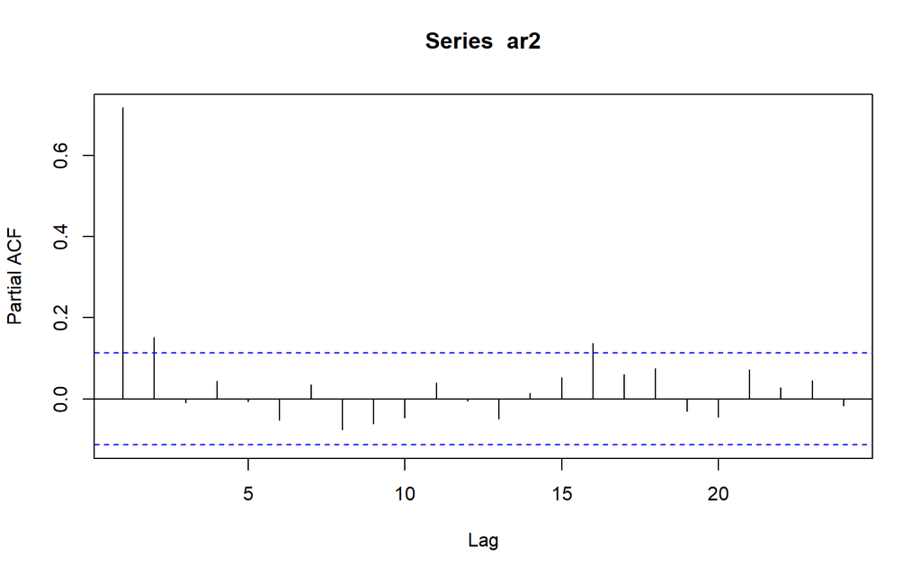

```r
pacf(ar2)
```

Berdasarkan plot PACF tersebut, terlihat bahwa plot PACF **cuts off** setelah lag kedua

## Plot EACF

```r
TSA::eacf(ar2)
```

```
## AR/MA
##   0 1 2 3 4 5 6 7 8 9 10 11 12 13
## 0 x x x x x x x x o o o  o  o  o
## 1 x o o o o o o o o o o  o  o  o
## 2 o o o o o o o o o o o  o  o  o
## 3 x x o o o o o o o o o  o  o  o
## 4 x x o o o o o o o o o  o  o  o
## 5 o x o x o o x o o o o  o  o  o
## 6 x x x x o o o o o o o  o  o  o
## 7 x x x o x x o o o o o  o  o  o
```

Berdasarkan plot EACF, terlihat bahwa segitiga nol berada pada ordo AR(2) dan ordo MA(1)

# Scatterplot Antar Lag AR(2)

*Buat scatterplot antara 𝑌𝑡 dengan 𝑌𝑡−1, 𝑌𝑡 dengan 𝑌𝑡−2 serta 𝑌𝑡 dengan 𝑌𝑡−3*

## Korelasi $Y_t$ dengan $Y_{t-1}$

```r
#Yt
yt_ar2 <- ar2[2:300]
yt_ar2
```

```
##   [1] -0.326103633  0.679976211 -2.070930324 -0.470345231 -0.143302788
##   [6] -0.740460400 -0.945522614 -1.185305386 -1.671795045 -1.550151299
##  [11] -2.107821103 -2.140194706 -1.427202757 -0.182146261 -0.486799176
##  [16] -0.790838346 -1.403974425 -1.697326562  1.286377013  0.437811414
##  [21] -0.014504787 -0.360237983  0.276569492 -0.627483098 -1.706632561
##  [26] -0.404057179 -1.567010825 -0.879455148 -1.689078340  0.081867346
##  [31] -0.772475074 -1.079304105 -1.195405128 -2.442656854 -2.628028715
##  [36] -3.982585377 -3.857891624 -3.019756746 -2.747354238 -0.528132203
##  [41] -1.882179673 -1.902080911 -1.608099392 -2.178805954 -2.379537173
##  [46] -2.732847970 -3.094317305 -2.617556366 -2.424491601 -3.541788331
##  [51] -2.837868410 -3.236181496 -3.200626439 -2.409859042 -1.281998990
##  [56]  0.524846169 -0.767330137  1.327213794 -0.647667678  0.598197384
##  [61]  2.718556227  1.444157201  0.596156266  0.579304817  2.185968110
##  [66]  0.070237282  1.840139442  2.263681968  1.836341670  1.377800067
##  [71]  0.600699629  0.209385895  0.873119441  2.548707761  1.295579356
```

[output cut: 45 more lines]

```r
#Yt-1
yt_1_ar2 <- ar2[1:299]
yt_1_ar2
```

```
##   [1] -1.207065749 -0.326103633  0.679976211 -2.070930324 -0.470345231
##   [6] -0.143302788 -0.740460400 -0.945522614 -1.185305386 -1.671795045
##  [11] -1.550151299 -2.107821103 -2.140194706 -1.427202757 -0.182146261
##  [16] -0.486799176 -0.790838346 -1.403974425 -1.697326562  1.286377013
##  [21]  0.437811414 -0.014504787 -0.360237983  0.276569492 -0.627483098
##  [26] -1.706632561 -0.404057179 -1.567010825 -0.879455148 -1.689078340
##  [31]  0.081867346 -0.772475074 -1.079304105 -1.195405128 -2.442656854
##  [36] -2.628028715 -3.982585377 -3.857891624 -3.019756746 -2.747354238
##  [41] -0.528132203 -1.882179673 -1.902080911 -1.608099392 -2.178805954
##  [46] -2.379537173 -2.732847970 -3.094317305 -2.617556366 -2.424491601
##  [51] -3.541788331 -2.837868410 -3.236181496 -3.200626439 -2.409859042
##  [56] -1.281998990  0.524846169 -0.767330137  1.327213794 -0.647667678
##  [61]  0.598197384  2.718556227  1.444157201  0.596156266  0.579304817
##  [66]  2.185968110  0.070237282  1.840139442  2.263681968  1.836341670
##  [71]  1.377800067  0.600699629  0.209385895  0.873119441  2.548707761
```

[output cut: 45 more lines]

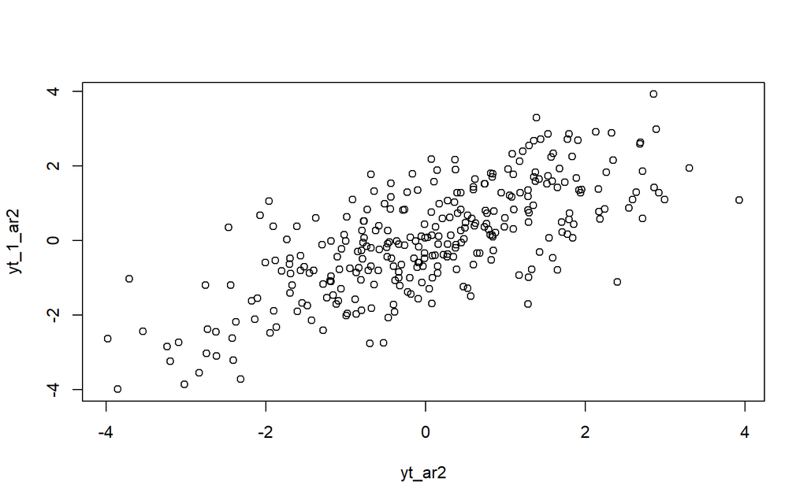

```r
#plot Yt dengan Yt-1
plot(yt_ar2,yt_1_ar2)
```

Berdasarakan scatterplot tersebut, terlihat bahwa data AR(2) memiliki korelasi positif yang cukup tinggi antara $Y_t$ dengan $Y_{t-1}$.

```r
#korelasi Yt dengan Yt-1
cor(yt_ar2,yt_1_ar2)
```

```
## [1] 0.7181941
```

Saat dicek dengan korelasi secara teoritis hasil yang hampir mirip dengan simulasi, yaitu

$$\rho_1=\frac{-\phi_1}{1+(-\phi_2)^2}=\frac{-(-0.5)}{1+(-0.2)^2}=0.625$$

## Korelasi $Y_t$ dengan $Y_{t-2}$

```r
#Yt
yt_ar2 <- ar2[3:300]
yt_ar2
```

```
##   [1]  0.679976211 -2.070930324 -0.470345231 -0.143302788 -0.740460400
##   [6] -0.945522614 -1.185305386 -1.671795045 -1.550151299 -2.107821103
##  [11] -2.140194706 -1.427202757 -0.182146261 -0.486799176 -0.790838346
##  [16] -1.403974425 -1.697326562  1.286377013  0.437811414 -0.014504787
##  [21] -0.360237983  0.276569492 -0.627483098 -1.706632561 -0.404057179
##  [26] -1.567010825 -0.879455148 -1.689078340  0.081867346 -0.772475074
##  [31] -1.079304105 -1.195405128 -2.442656854 -2.628028715 -3.982585377
##  [36] -3.857891624 -3.019756746 -2.747354238 -0.528132203 -1.882179673
##  [41] -1.902080911 -1.608099392 -2.178805954 -2.379537173 -2.732847970
##  [46] -3.094317305 -2.617556366 -2.424491601 -3.541788331 -2.837868410
##  [51] -3.236181496 -3.200626439 -2.409859042 -1.281998990  0.524846169
##  [56] -0.767330137  1.327213794 -0.647667678  0.598197384  2.718556227
##  [61]  1.444157201  0.596156266  0.579304817  2.185968110  0.070237282
##  [66]  1.840139442  2.263681968  1.836341670  1.377800067  0.600699629
##  [71]  0.209385895  0.873119441  2.548707761  1.295579356 -0.233169716
```

[output cut: 45 more lines]

```r
#Yt-2
yt_2_ar2 <- ar2[1:298]
yt_2_ar2
```

```
##   [1] -1.207065749 -0.326103633  0.679976211 -2.070930324 -0.470345231
##   [6] -0.143302788 -0.740460400 -0.945522614 -1.185305386 -1.671795045
##  [11] -1.550151299 -2.107821103 -2.140194706 -1.427202757 -0.182146261
##  [16] -0.486799176 -0.790838346 -1.403974425 -1.697326562  1.286377013
##  [21]  0.437811414 -0.014504787 -0.360237983  0.276569492 -0.627483098
##  [26] -1.706632561 -0.404057179 -1.567010825 -0.879455148 -1.689078340
##  [31]  0.081867346 -0.772475074 -1.079304105 -1.195405128 -2.442656854
##  [36] -2.628028715 -3.982585377 -3.857891624 -3.019756746 -2.747354238
##  [41] -0.528132203 -1.882179673 -1.902080911 -1.608099392 -2.178805954
##  [46] -2.379537173 -2.732847970 -3.094317305 -2.617556366 -2.424491601
##  [51] -3.541788331 -2.837868410 -3.236181496 -3.200626439 -2.409859042
##  [56] -1.281998990  0.524846169 -0.767330137  1.327213794 -0.647667678
##  [61]  0.598197384  2.718556227  1.444157201  0.596156266  0.579304817
##  [66]  2.185968110  0.070237282  1.840139442  2.263681968  1.836341670
##  [71]  1.377800067  0.600699629  0.209385895  0.873119441  2.548707761
```

[output cut: 45 more lines]

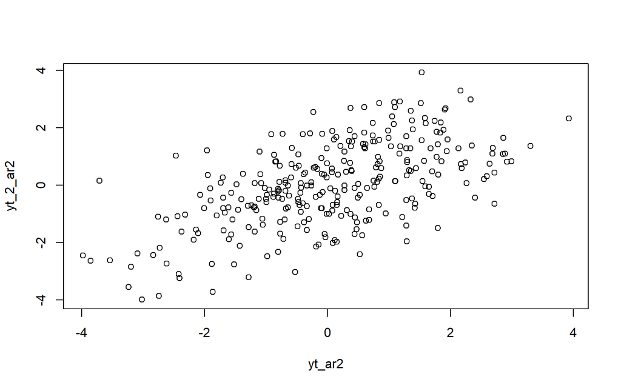

```r
#plot Yt dengan Yt-2
plot(yt_ar2,yt_2_ar2)
```

Berdsarkan scatterplot tersebut, terlihat bahwa data AR(2) antara $Y_t$ dengan $Y_{t-2}$ memiliki korelasi positif yang lebih rendah dari $Y_t$ dengan $Y_{t-1}$.

```r
#korelasi Yt dengan Yt-2
cor(yt_ar2,yt_2_ar2)
```

```
## [1] 0.5889847
```

## Korelasi $Y_t$ dengan $Y_{t-3}$

```r
#Yt
yt_ar2 <- ar2[4:300]
yt_ar2
```

```
##   [1] -2.070930324 -0.470345231 -0.143302788 -0.740460400 -0.945522614
##   [6] -1.185305386 -1.671795045 -1.550151299 -2.107821103 -2.140194706
##  [11] -1.427202757 -0.182146261 -0.486799176 -0.790838346 -1.403974425
##  [16] -1.697326562  1.286377013  0.437811414 -0.014504787 -0.360237983
##  [21]  0.276569492 -0.627483098 -1.706632561 -0.404057179 -1.567010825
##  [26] -0.879455148 -1.689078340  0.081867346 -0.772475074 -1.079304105
##  [31] -1.195405128 -2.442656854 -2.628028715 -3.982585377 -3.857891624
##  [36] -3.019756746 -2.747354238 -0.528132203 -1.882179673 -1.902080911
##  [41] -1.608099392 -2.178805954 -2.379537173 -2.732847970 -3.094317305
##  [46] -2.617556366 -2.424491601 -3.541788331 -2.837868410 -3.236181496
##  [51] -3.200626439 -2.409859042 -1.281998990  0.524846169 -0.767330137
##  [56]  1.327213794 -0.647667678  0.598197384  2.718556227  1.444157201
##  [61]  0.596156266  0.579304817  2.185968110  0.070237282  1.840139442
##  [66]  2.263681968  1.836341670  1.377800067  0.600699629  0.209385895
##  [71]  0.873119441  2.548707761  1.295579356 -0.233169716 -0.581050764
```

[output cut: 45 more lines]

```r
#Yt-3
yt_3_ar2 <- ar2[1:297]
yt_3_ar2
```

```
##   [1] -1.207065749 -0.326103633  0.679976211 -2.070930324 -0.470345231
##   [6] -0.143302788 -0.740460400 -0.945522614 -1.185305386 -1.671795045
##  [11] -1.550151299 -2.107821103 -2.140194706 -1.427202757 -0.182146261
##  [16] -0.486799176 -0.790838346 -1.403974425 -1.697326562  1.286377013
##  [21]  0.437811414 -0.014504787 -0.360237983  0.276569492 -0.627483098
##  [26] -1.706632561 -0.404057179 -1.567010825 -0.879455148 -1.689078340
##  [31]  0.081867346 -0.772475074 -1.079304105 -1.195405128 -2.442656854
##  [36] -2.628028715 -3.982585377 -3.857891624 -3.019756746 -2.747354238
##  [41] -0.528132203 -1.882179673 -1.902080911 -1.608099392 -2.178805954
##  [46] -2.379537173 -2.732847970 -3.094317305 -2.617556366 -2.424491601
##  [51] -3.541788331 -2.837868410 -3.236181496 -3.200626439 -2.409859042
##  [56] -1.281998990  0.524846169 -0.767330137  1.327213794 -0.647667678
##  [61]  0.598197384  2.718556227  1.444157201  0.596156266  0.579304817
##  [66]  2.185968110  0.070237282  1.840139442  2.263681968  1.836341670
##  [71]  1.377800067  0.600699629  0.209385895  0.873119441  2.548707761
```

[output cut: 45 more lines]

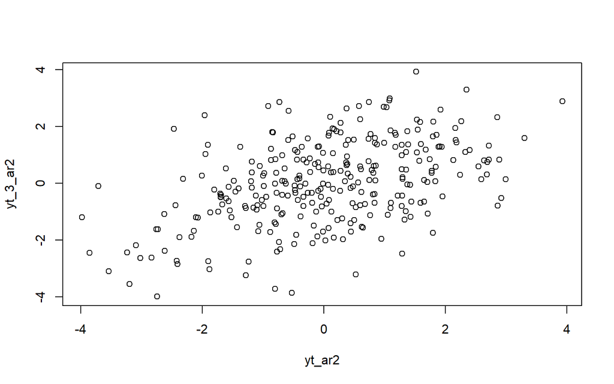

```r
#plot Yt dengan Yt-3
plot(yt_ar2,yt_3_ar2)
```

```r
#korelasi Yt dengan Yt-3
cor(yt_ar2,yt_3_ar2)
```

```
## [1] 0.4630342
```

# Proses ARMA(2,2)

*Bangkitkan model ARMA(2,2) dengan 𝜃1 = 0.4, 𝜃2 = 0.6 ,𝜙1 = 0.5 dan 𝜙2 = 0.2 sebanyak 300 data (Manual dan arima.sim)*

bentuk umum data berpola ARMA.

$$y_{t} = c + \sum_{i=1}^p \phi_{i}y_{t-i} + \sum_{j=1}^q e_{t-j}+ e_{t}$$

## Dengan Manual

```r
phi1 = 0.5
phi2 = 0.2
theta1 = 0.4
theta2 = 0.6

arma22 <- c(1:n)
arma22[1] <- wn[1]
arma22[2] <- wn[2]+phi1*arma22[1]
for (i in 3:n) {
  arma22[i]<-wn[i]+phi1*arma22[i-1]+phi2*arma22[i-2]-theta1*wn[i-1]-theta2*wn[i-2]
}
arma22
```

```
##   [1] -1.207065749 -0.326103633  1.293243963 -2.364530463 -0.206877375
##   [6]  1.165479858 -0.493272676 -0.633909774 -0.416564703 -0.671342222
##  [11] -0.201490420 -0.508500322 -0.385131942  0.679726207  1.662299584
##  [16]  0.434336625 -0.492963514 -0.800234750 -0.664797888  2.804975207
##  [21]  0.939585183 -0.963034659 -0.618326739  0.428449827 -0.522667734
##  [26] -1.622114378  0.654679097 -0.381718392 -0.010452820 -0.397269936
##  [31]  1.285034435  0.208120294 -0.819514300 -0.300259289 -1.316958727
##  [36] -0.933758260 -1.465806738 -0.688060796  0.912935462  0.775271490
##  [41]  2.382654434 -0.022521190 -0.832335012  0.282036742 -0.394320727
##  [46] -0.543157501 -0.473751316 -0.573457176  0.259878300  0.479120536
##  [51] -1.001458474  0.033541422  0.024038516 -0.203433062  0.812100227
##  [56]  1.602320335  2.483561072 -0.208069301  1.319238079 -0.718155166
##  [61]  0.060936139  2.867877850 -0.002183744 -1.612640368 -0.525652023
##  [66]  1.596552413 -1.151732861  0.500463658  1.485483818 -0.173214786
##  [71] -0.714945785 -1.052225401 -0.857573998  0.428945304  2.073828446
```

[output cut: 45 more lines]

## Dengan Arima.sim()

```r
armasim22 <- arima.sim(list(order=c(2,0,2), ar=c(0.5,0.2), ma=c(0.4,0.6)), n=300)
armasim22
```

```
## Time Series:
## Start = 1
## End = 300
## Frequency = 1
##   [1] -2.16055656 -0.45018472 -1.39327611 -1.03395069 -1.13310653 -0.85191297
##   [7]  1.17212092 -0.93924298  0.72818720 -0.68463136  1.20847833  0.75544112
##  [13] -1.59243313 -1.38000929 -2.70260074 -2.45182575 -2.94967161 -2.76573816
##  [19]  0.10764412  0.70307151  0.93987571  2.23518822  1.04067584  1.10440783
##  [25] -1.08189454 -1.99060305 -0.29437563  0.73103442  2.56689379  2.41482665
##  [31]  2.50447906  2.52570508  2.38518100  2.29269057  2.76873910  2.15161756
##  [37]  2.39051525  0.73059865  2.22138578  2.74467588  1.51184238  1.19928857
##  [43]  0.27798601  0.95173757  1.81532284  1.24633215  0.05914326 -0.16922338
##  [49] -2.21454162 -0.94052281 -0.87955680 -1.87136268 -0.51325333 -1.62335245
##  [55] -1.11458764 -0.84039884  0.41152507  2.38253221  1.46744740  1.23139484
##  [61]  0.16016278  0.18831505 -0.20460942 -2.54515705 -2.79574934 -4.60533009
```

[output cut: 39 more lines]

# Karakterisitik ARMA(2,2)

*Buat plot time series, plot ACF, plot PACF dan plot EACF. Idenifikasi apakah data tersebut stasioner*

## Plot Time Series

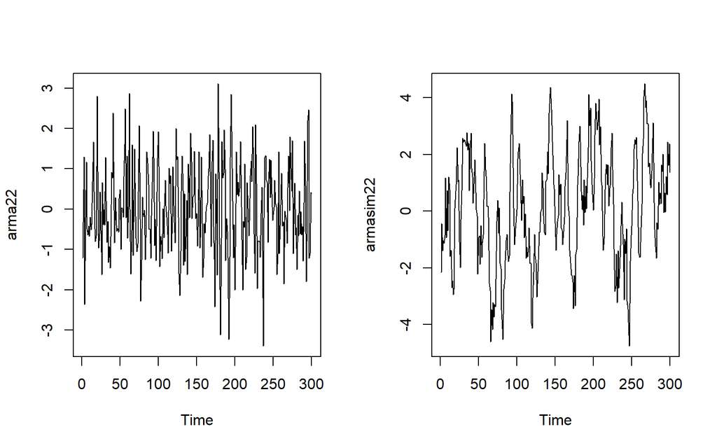

```r
par(mfrow=c(1,2))
ts.plot(arma22)
ts.plot(armasim22)
```

Dari plot tersebut terlihat bahwa data ARMA(2,2) dibangkitkan stasioner dalam rataan

## Plot ACF

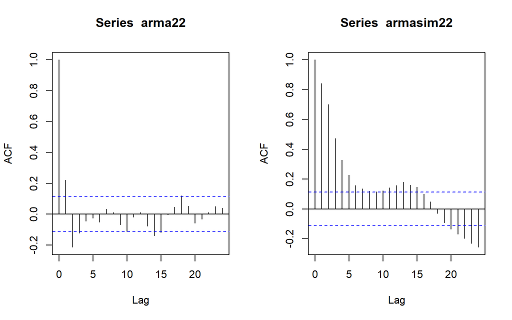

```r
par(mfrow=c(1,2))
acf(arma22)
acf(armasim22)
```

Berdasarkan plot ACF tersebut, baik data bangkitan secara manual maupun secara armasim terlihat bahwa plot ACF memiliki pola **tails off**.

## Plot PACF

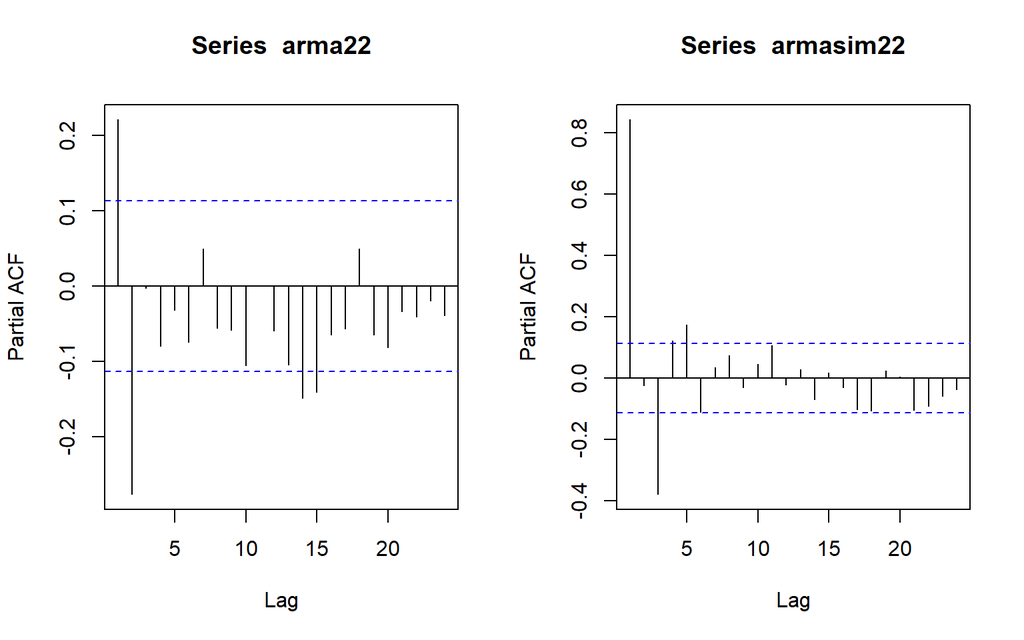

```r
par(mfrow=c(1,2))
pacf(arma22)
pacf(armasim22)
```

Berdasarkan plot PACF tersebut, baik data bangkitan secara manual maupun secara armasim terlihat bahwa plot PACF memiliki pola **tails off**

## Plot EACF

```r
TSA::eacf(arma22)
```

```
## AR/MA
##   0 1 2 3 4 5 6 7 8 9 10 11 12 13
## 0 x x x o o o o o o o o  o  o  x
## 1 x x o o o o o o o o o  o  o  o
## 2 o x x o o o o o o o o  o  o  o
## 3 o x o x o o o o o o o  o  o  o
## 4 x x o x o o o o o o o  o  o  o
## 5 x x x x o o o o o o o  o  o  o
## 6 x x x x x o o o o o o  o  o  o
## 7 x o x x o o o o o o o  o  o  o
```

```r
TSA::eacf(armasim22)
```

```
## AR/MA
##   0 1 2 3 4 5 6 7 8 9 10 11 12 13
## 0 x x x x x x x x o x x  x  x  x
## 1 o x o o o o o o o o o  o  x  o
## 2 o x o o o o o o o o o  o  x  o
## 3 x x o o o o o o o o o  o  o  o
## 4 x x o o x o o o o o o  o  o  o
## 5 x x x o o o o o o o o  o  o  o
## 6 x x x o x o o o o o o  o  o  o
## 7 x x x o x o o o o o o  o  o  o
```

# Scatterplot Antar Lag ARMA(2,2)

*Buat scatterplot antara 𝑌𝑡 dengan 𝑌𝑡−1, 𝑌𝑡 dengan 𝑌𝑑−2 serta 𝑌𝑡 dengan 𝑌𝑑−3*

## Korelasi $Y_t$ dengan $Y_{t-1}$

```r
#Yt
yt_arma22 <- arma22[2:300]
yt_arma22
```

```
##   [1] -0.326103633  1.293243963 -2.364530463 -0.206877375  1.165479858
##   [6] -0.493272676 -0.633909774 -0.416564703 -0.671342222 -0.201490420
##  [11] -0.508500322 -0.385131942  0.679726207  1.662299584  0.434336625
##  [16] -0.492963514 -0.800234750 -0.664797888  2.804975207  0.939585183
##  [21] -0.963034659 -0.618326739  0.428449827 -0.522667734 -1.622114378
##  [26]  0.654679097 -0.381718392 -0.010452820 -0.397269936  1.285034435
##  [31]  0.208120294 -0.819514300 -0.300259289 -1.316958727 -0.933758260
##  [36] -1.465806738 -0.688060796  0.912935462  0.775271490  2.382654434
##  [41] -0.022521190 -0.832335012  0.282036742 -0.394320727 -0.543157501
##  [46] -0.473751316 -0.573457176  0.259878300  0.479120536 -1.001458474
##  [51]  0.033541422  0.024038516 -0.203433062  0.812100227  1.602320335
##  [56]  2.483561072 -0.208069301  1.319238079 -0.718155166  0.060936139
##  [61]  2.867877850 -0.002183744 -1.612640368 -0.525652023  1.596552413
##  [66] -1.151732861  0.500463658  1.485483818 -0.173214786 -0.714945785
##  [71] -1.052225401 -0.857573998  0.428945304  2.073828446 -0.247775413
```

[output cut: 45 more lines]

```r
#Yt-1
yt_1_arma22 <- arma22[1:299]
yt_1_arma22
```

```
##   [1] -1.207065749 -0.326103633  1.293243963 -2.364530463 -0.206877375
##   [6]  1.165479858 -0.493272676 -0.633909774 -0.416564703 -0.671342222
##  [11] -0.201490420 -0.508500322 -0.385131942  0.679726207  1.662299584
##  [16]  0.434336625 -0.492963514 -0.800234750 -0.664797888  2.804975207
##  [21]  0.939585183 -0.963034659 -0.618326739  0.428449827 -0.522667734
##  [26] -1.622114378  0.654679097 -0.381718392 -0.010452820 -0.397269936
##  [31]  1.285034435  0.208120294 -0.819514300 -0.300259289 -1.316958727
##  [36] -0.933758260 -1.465806738 -0.688060796  0.912935462  0.775271490
##  [41]  2.382654434 -0.022521190 -0.832335012  0.282036742 -0.394320727
##  [46] -0.543157501 -0.473751316 -0.573457176  0.259878300  0.479120536
##  [51] -1.001458474  0.033541422  0.024038516 -0.203433062  0.812100227
##  [56]  1.602320335  2.483561072 -0.208069301  1.319238079 -0.718155166
##  [61]  0.060936139  2.867877850 -0.002183744 -1.612640368 -0.525652023
##  [66]  1.596552413 -1.151732861  0.500463658  1.485483818 -0.173214786
##  [71] -0.714945785 -1.052225401 -0.857573998  0.428945304  2.073828446
```

[output cut: 45 more lines]

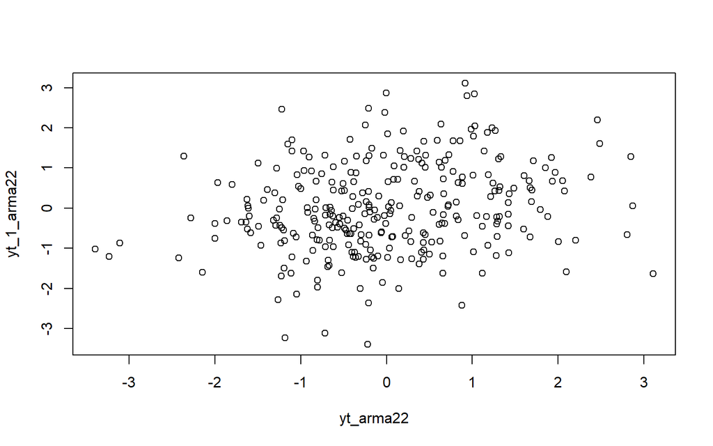

```r
#plot Yt dengan Yt-1
plot(yt_arma22,yt_1_arma22)
```

Berdasarkan scatterplot tersebut, terlihat bahwa data ARMA(2,2) memiliki korelasi positif yang sangat kecil antara $Y_t$ dengan $Y_{t-1}$.

```r
#korelasi Yt dengan Yt-1
cor(yt_arma22,yt_1_arma22)
```

```
## [1] 0.2215858
```

## Korelasi $Y_t$ dengan $Y_{t-2}$

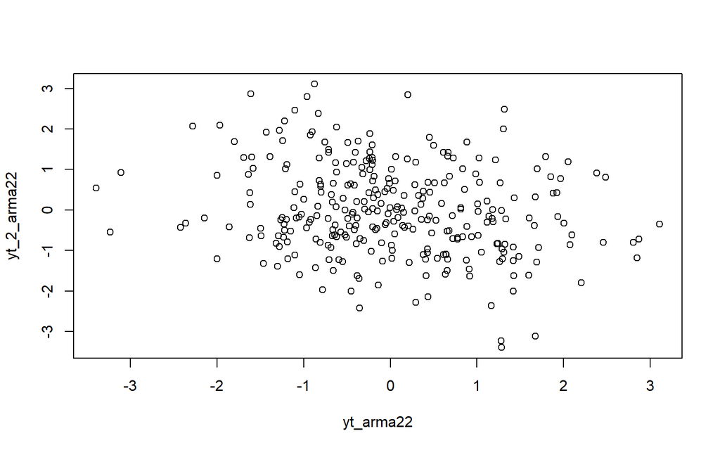

```r
#Yt
yt_arma22 <- arma22[3:300]

#Yt-2
yt_2_arma22 <- arma22[1:298]

#plot Yt dengan Yt-2
plot(yt_arma22,yt_2_arma22)
```

Berdasarkan scatterplot tersebut, terlihat bahwa data ARMA(2,2) antara $Y_t$ dengan $Y_{t-2}$ memiliki korelasi negatif yang sangat kecil.

```r
#korelasi Yt dengan Yt-2
cor(yt_arma22,yt_2_arma22)
```

```
## [1] -0.2147718
```

## Korelasi $Y_t$ dengan $Y_{t-3}$

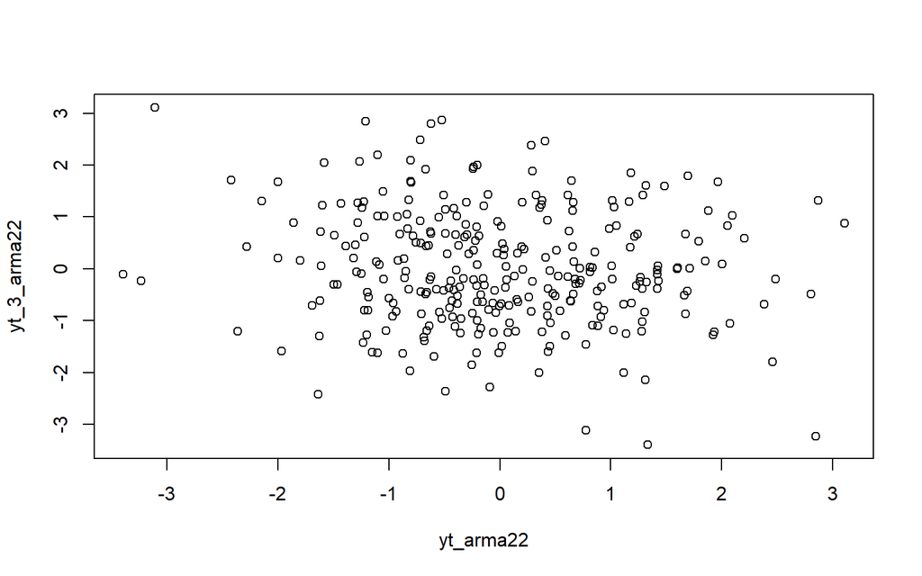

```r
#Yt
yt_arma22 <- arma22[4:300]

#Yt-3
yt_3_arma22 <- arma22[1:297]

#plot Yt dengan Yt-3
plot(yt_arma22,yt_3_arma22)
```

Berdasarkan scatterplot tersebut, terlihat bahwa data ARMA(2,2) cenderung tidak memiliki korelasi antara $Y_t$ dengan $Y_{t-3}$.

```r
#korelasi Yt dengan Yt-3
cor(yt_arma22,yt_3_arma22)
```

```
## [1] -0.1244934
```